# Data processing

This is the companion notebook dedicated to data processing. This stage can easily be overlooked but is **crucial in machine learning**. We briefly discuss categorical variables and logistic regression. We also make a few steps towards ML-driven factor investing in the last section.

$\rightarrow$ **ABOUT THE NOTEBOOK**:

- the code chunks are **sequential**. They must be executed in the correct order.
- text between **stars** appears in bold in html format.

## Introduction

We choose to skip the complicated topic of outlier detection to focus directly on feature engineering (we refer to Aggarwal (2016) for an in-depth treatment of outlier analysis). Below, we start with artificially generated data and introduce simple **rescaling methods**.

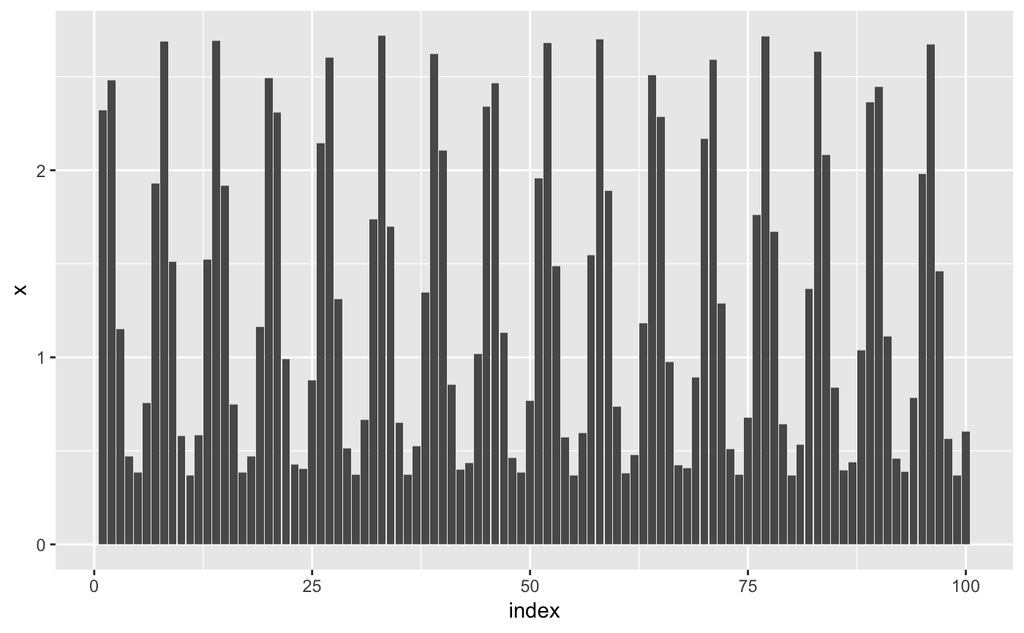

```r
library(tidyverse)                          # Loading THE package/environment
Length <- 100                               # Length of the sequence
x <- exp(sin(1:Length))                     # Original data
data <- data.frame(index = 1:Length, x = x) # Data framed into dataframe
ggplot(data, aes(x = index, y = x)) + geom_bar(stat = "identity") # Plot
```

Nothing special about this sample. We choose to work with positive values, but this is without much loss of generality. Below, we scale the variable using 3 methods:

1. **standardisation**: $\tilde{x}_i=(x_i-m)/\sigma$, where $m$ is the mean and $\sigma$ the standard deviation of the sample
2. **min-max rescaling**: $\tilde{x_i}=(x_i-min(x))/(max(x)-min(x))$
3. **‘uniformisation’**: $\tilde{x}_i=ecdf(x)$, where ecdf is the empirical cumulative distribution function of the sample

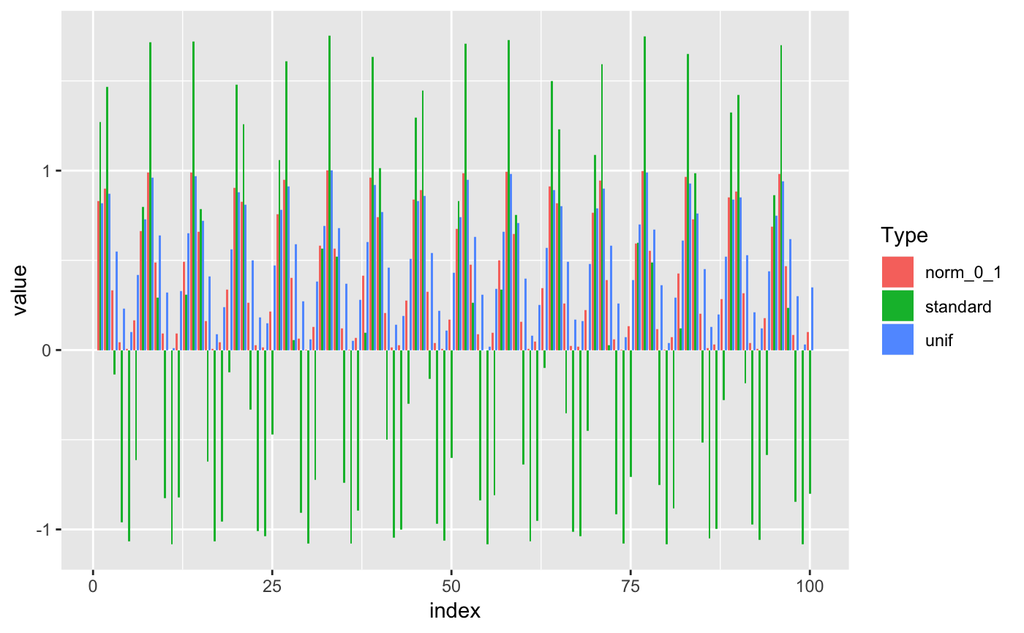

```r
standard <- (x - mean(x)) / sd(x)           # Standardisation
norm_0_1 <- (x - min(x)) / (max(x)-min(x))  # [0,1] reduction
unif <- ecdf(x)(x)                          # Uniformisation
data_norm <- data.frame(                    # Formatting the data
    index = 1:Length,                       # Index of point/instance
    standard = standard,
    norm_0_1 = norm_0_1,
    unif = unif) %>% gather(key = Type, value = value, -index)
ggplot(data_norm, aes(x = index, y = value, fill = Type)) +   # Plot!
    geom_bar(stat = "identity", position = "dodge")
```

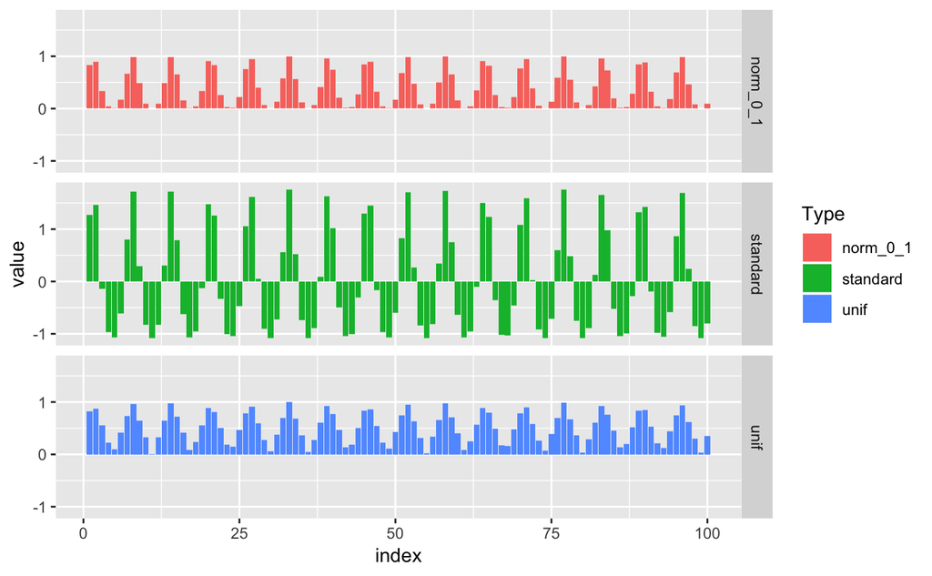

```r
ggplot(data_norm, aes(x = index, y = value, fill = Type)) +   # Plot!
    geom_bar(stat = "identity") +
    facet_grid(Type~.)          # This option creates 3 concatenated graphs to ease comparison
```

By definition, standardisation produces both **positive** and **negative** values.  
In terms of distribution of the data, this gives the following differences:

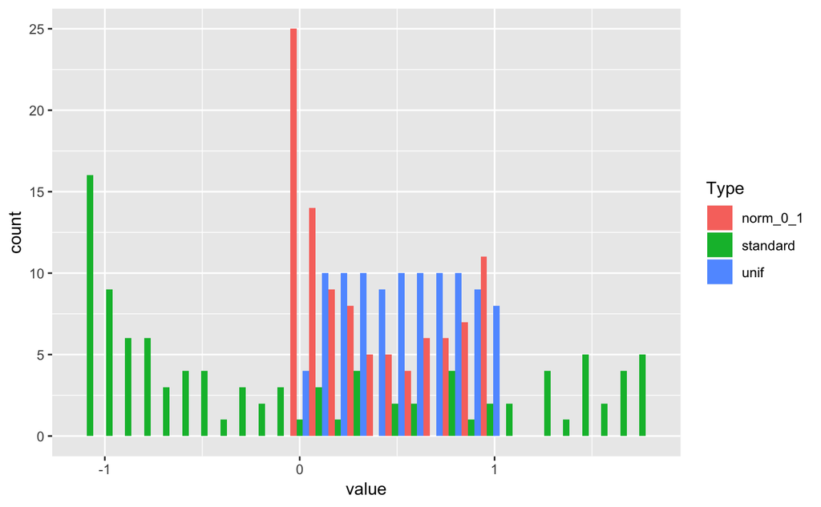

```r
ggplot(data_norm, aes(x = value, fill = Type)) + geom_histogram(position = "dodge")
```

With respect to shape, the green and red distributions are close to the original one. It is only the support that changes: the min/max rescaling ensures all values lie in the [0,1] interval. In both cases, the smallest values (on the left) display a spike in distribution. By construction, this spike disappears under the **uniformisation**: the points are evenly distributed over the unit interval.

## Application to financial data

In this section, we investigate the impact of these techniques and choices on simple analyses. We compare the impact of rescaling on basic regression results.

### Baseline results

We start by importing the data and computing returns (our dependent variable).

```r
load("data.RData")
data <- data %>% arrange(Date,Tick)                     # Just making sure all is in order
tick <- levels(data$Tick)                               # Set of assets
data <- data  %>%
    group_by(Tick) %>%                                  # Perform analysis stock-by-stock
    mutate(F_Return = lead(Close) / Close - 1) %>%      # Adding forward/future returns
    na.omit() %>%                                       # Take out missing data
    ungroup()
summary(data)                                           # Descriptive statistics
```

```
      Tick           Date                Close            Mkt_Cap            P2B
 AAPL   : 220   Min.   :2000-01-03   Min.   :  1.004   Min.   :  4491   Min.   :   0.0922
 BA     : 220   1st Qu.:2004-07-25   1st Qu.: 28.023   1st Qu.: 63349   1st Qu.:   2.0786
 BAC    : 220   Median :2009-02-16   Median : 42.435   Median :128539   Median :   3.1016
 C      : 220   Mean   :2009-02-15   Mean   : 57.355   Mean   :145455   Mean   :   6.6556
 CSCO   : 220   3rd Qu.:2013-09-09   3rd Qu.: 65.775   3rd Qu.:198112   3rd Qu.:   5.2970
 CVS    : 220   Max.   :2018-04-02   Max.   :557.000   Max.   :887952   Max.   :1259.1554
 (Other):5280
     Vol_1M            RSI_1M           D2E             Prof_Marg           F_Return
 Min.   :  5.276   Min.   :22.04   Min.   :    0.00   Min.   :-106.260   Min.   :-0.671233
 1st Qu.: 15.734   1st Qu.:46.14   1st Qu.:   29.35   1st Qu.:   5.122   1st Qu.:-0.033786
 Median : 21.542   Median :51.61   Median :   60.27   Median :  10.138   Median : 0.006888
 Mean   : 26.896   Mean   :51.66   Mean   :  191.19   Mean   :  11.736   Mean   : 0.006472
 3rd Qu.: 31.830   3rd Qu.:57.13   3rd Qu.:  204.45   3rd Qu.:  18.860   3rd Qu.: 0.048684
 Max.   :265.429   Max.   :84.84   Max.   :14585.61   Max.   : 145.583   Max.   : 1.233333
```

First, the **descriptive statistics**. Looking at the dispersion between the median and both the minimum and maximum gives a first impression on outliers. For instance, the maximum **D2E** is 242 times the median: this is a big number. The same observation holds for **P2B**. Sometimes, it is worthwhile to understand if these values are errors or due to very small values in the denominator. For instance, the outlier in P2B comes from very low **book values** for **Boeing** in 2017.

Then, we rescale the predictors (features). We use two normalising functions. For consistency reasons, we will compare the two methods that scale inputs into the [0,1] interval. One secondary reason for that is that some ML tools work well/better with bounded inputs (neural networks for instance). Below, we create the two dataframes used in the analysis.

**NOTE**: it is imperative to rescale the data **AT EACH DATE**.

```r
norm_unif <-  function(v){  # This is a function that uniformalises a vector.
    v <- v %>% as.matrix()
    return(ecdf(v)(v))
}
norm_0_1 <-  function(v){  # This is a function that uniformalises a vector.
    return((v-min(v))/(max(v)-min(v)))
}
data_0 <- data %>%                          # Data with normalised values
    group_by(Date) %>%                      # Normalisation takes place for each given date
    mutate_if(is.numeric, norm_0_1) %>%     # Apply normalisation on numerical columns
    ungroup() %>%                           # Ungroup
    select(-Tick, -Date, -Close)            # Take out superfluous columns
```

```
`mutate_if()` ignored the following grouping variables:
Column `Date`
```

```r
data_0$F_Return <- data$F_Return            # We recover the original returns
data_u <- data %>%                          # Data with normalised values
    group_by(Date) %>%                      # Normalisation takes place for each given date
    mutate_if(is.numeric, norm_unif) %>%    # Apply normalisation on numerical columns
    ungroup() %>%                           # Ungroup
    select(-Tick, -Date, -Close)            # Take out superfluous columns
```

```
`mutate_if()` ignored the following grouping variables:
Column `Date`
```

```r
data_u$F_Return <- data$F_Return            # We recover the original returns
```

Below, we check the distribution of the variables.

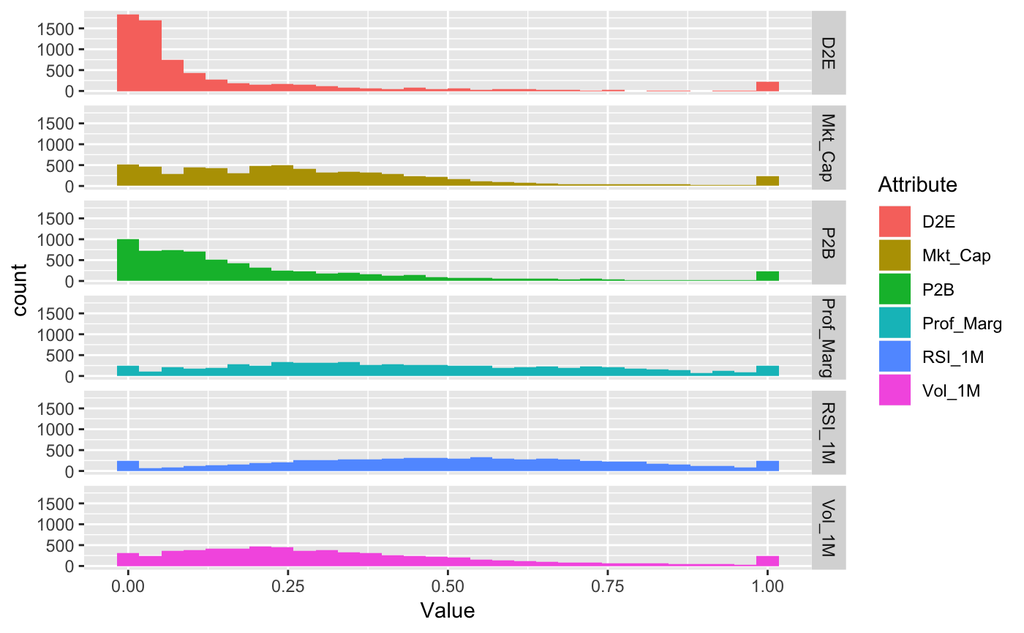

```r
data_0 %>%
    select(-F_Return) %>%                       # Remove returns
    gather(key = Attribute, value = Value) %>%  # Convert to 'compact' column mode
    ggplot(aes(x = Value, fill = Attribute)) +
    geom_histogram() +                          # Plot histograms
    facet_grid(Attribute~.)                     # Stack the histograms
```

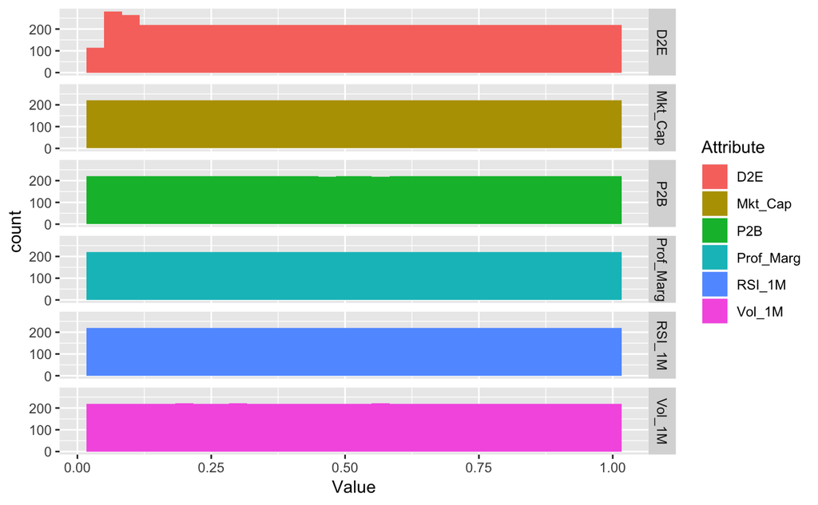

```r
data_u %>%
    select(-F_Return) %>%                       # Remove returns
    gather(key = Attribute, value = Value) %>%  # Convert to 'compact' mode
    ggplot(aes(x = Value, fill = Attribute)) +
    geom_histogram() +                          # Plot histograms
    facet_grid(Attribute~.)                     # Stack the histograms
```

Apart for a minor issue with D2E (due to outliers?), the scaling seems ok. But clearly, the distribution of all variables are strongly impacted by the scaling choice.

We are now ready to perform the regressions. We start with the scaled data.

```r
fit <- lm(F_Return ~ ., data = data_0)      # Regression on first set
summary(fit)                                # Regression output
```

```
Call:
lm(formula = F_Return ~ ., data = data_0)

Residuals:
     Min       1Q   Median       3Q      Max
-0.69065 -0.03975  0.00126  0.04272  1.21352

Coefficients:
              Estimate Std. Error t value Pr(>|t|)
(Intercept)  0.0172117  0.0036242   4.749 2.09e-06 ***
Mkt_Cap     -0.0152789  0.0045072  -3.390 0.000703 ***
P2B         -0.0073716  0.0042592  -1.731 0.083542 .
Vol_1M       0.0040129  0.0041964   0.956 0.338961
RSI_1M      -0.0085898  0.0040551  -2.118 0.034190 *
D2E          0.0006681  0.0047176   0.142 0.887388
Prof_Marg   -0.0035985  0.0039977  -0.900 0.368070
---
Signif. codes:  0 ‘***’ 0.001 ‘**’ 0.01 ‘*’ 0.05 ‘.’ 0.1 ‘ ’ 1

Residual standard error: 0.08417 on 6593 degrees of freedom
Multiple R-squared:  0.004166,  Adjusted R-squared:  0.00326
F-statistic: 4.597 on 6 and 6593 DF,  p-value: 0.000115
```

If we set the significance threshold at 5%, then two variables stand out: **Mkt_Cap** (strongly) and **RSI_1M** (weakly). With this database, future returns are negatively related to firm size. This is true in all analyses that we can/will do (with trees, notably).

We now turn to the ‘**uniformised**’ data.

```r
fit <- lm(F_Return ~ ., data = data_u)      # Regression on second set
summary(fit)                                # Regression output
```

```
Call:
lm(formula = F_Return ~ ., data = data_u)

Residuals:
     Min       1Q   Median       3Q      Max
-0.68433 -0.03964  0.00147  0.04256  1.21885

Coefficients:
             Estimate Std. Error t value Pr(>|t|)
(Intercept)  0.021847   0.005142   4.249 2.18e-05 ***
Mkt_Cap     -0.020842   0.004146  -5.027 5.11e-07 ***
P2B         -0.006489   0.003706  -1.751   0.0800 .
Vol_1M       0.002892   0.003692   0.783   0.4335
RSI_1M      -0.006836   0.003622  -1.887   0.0592 .
D2E         -0.007617   0.003775  -2.018   0.0436 *
Prof_Marg    0.009145   0.004066   2.249   0.0245 *
---
Signif. codes:  0 ‘***’ 0.001 ‘**’ 0.01 ‘*’ 0.05 ‘.’ 0.1 ‘ ’ 1

Residual standard error: 0.08411 on 6593 degrees of freedom
Multiple R-squared:  0.005494,  Adjusted R-squared:  0.004589
F-statistic: 6.071 on 6 and 6593 DF,  p-value: 2.373e-06
```

In this case, **Mkt_Cap** is still strongly significant, buth RSI_1M’s impact has faded, while **D2E** and **Prof_Marg** emerge as weak drivers. This underlines the importance of **feature engineering**. For nonlinear models, we refer to Galili and Meilijson (2016 - arxiv) for an analysis of the impact of feature transformation on tree splits.

### A toy example

To illustrate the difference between the two rescaling methods, we build a simple dataset, comprising 3 firms and 3 dates.

```r
firm <- c(rep(1,3), rep(2,3), rep(3,3))             # Firms (3 lines for each)
date <- rep(c(1,2,3),3)                             # Dates
cap <- c(10, 50, 100,                               # Market capitalisation
         15, 10, 15,
         200, 120, 80)
return <- c(0.06, 0.01, -0.06,                      # Return values
            -0.03, 0.00, 0.02,
            -0.04, -0.02,0.00)
data_toy <- data.frame(firm, date, cap, return)     # Aggregation of data
data_toy <- data_toy %>%                            # Transformation of data
    group_by(date) %>%
    mutate(cap_0 = norm_0_1(cap), cap_u = norm_unif(cap))
data_toy                                            # Display the data
```

| firm | date | cap | return | cap_0 | cap_u |
| --- | --- | --- | --- | --- | --- |
| 1 | 1 | 10 | 0.06 | 0.00000000 | 0.3333333 |
| 1 | 2 | 50 | 0.01 | 0.36363636 | 0.6666667 |
| 1 | 3 | 100 | -0.06 | 1.00000000 | 1.0000000 |
| 2 | 1 | 15 | -0.03 | 0.02631579 | 0.6666667 |
| 2 | 2 | 10 | 0.00 | 0.00000000 | 0.3333333 |
| 2 | 3 | 15 | 0.02 | 0.00000000 | 0.3333333 |
| 3 | 1 | 200 | -0.04 | 1.00000000 | 1.0000000 |
| 3 | 2 | 120 | -0.02 | 1.00000000 | 1.0000000 |
| 3 | 3 | 80 | 0.00 | 0.76470588 | 0.6666667 |

Let’s briefly comment on this **synthetic data**. We assume that dates are ordered chronologically and far away: each date stands for a year or the beginning of a decade, but the (forward) returns are computed on a monthly basis. The first firm is hugely successful and multiplies its cap ten times over the periods. The second firms remains stable cap-wise, while the third one plummets. If we look at ‘local’ future returns, they are strongly negatively related to size for the first and third firms. For the second one, there is no clear pattern.

Date-by-date, the analysis is fairly similar, though slightly nuanced.

1. On **date 1**, the smallest firm has the largest return and the two others have negative returns.
2. On **date 2**, the biggest firm has a negative return while the two smaller firms do not.
3. On **date 3**, returns are decreasing with size.

While the relationship is not always perfectly monotonous, there seems to be a link between size and return and typically, investing in the smallest firm would be a very good strategy with this sample.

Now let’s look at the regressions.

```r
lm(return ~ cap_0, data = data_toy) %>% summary() # First regression (min-max rescaling)
```

```
Call:
lm(formula = return ~ cap_0, data = data_toy)

Residuals:
      Min        1Q    Median        3Q       Max
-0.044970 -0.016278  0.003722  0.013425  0.043722

Coefficients:
            Estimate Std. Error t value Pr(>|t|)
(Intercept)  0.01628    0.01374   1.185   0.2746
cap_0       -0.04970    0.02137  -2.326   0.0529 .
---
Signif. codes:  0 ‘***’ 0.001 ‘**’ 0.01 ‘*’ 0.05 ‘.’ 0.1 ‘ ’ 1

Residual standard error: 0.02867 on 7 degrees of freedom
Multiple R-squared:  0.4359,    Adjusted R-squared:  0.3553
F-statistic: 5.409 on 1 and 7 DF,  p-value: 0.05294
```

```r
lm(return ~ cap_u, data = data_toy) %>% summary() # Second regression (uniformised feature)
```

```
Call:
lm(formula = return ~ cap_u, data = data_toy)

Residuals:
     Min       1Q   Median       3Q      Max
-0.02667 -0.02000  0.00000  0.01667  0.03333

Coefficients:
            Estimate Std. Error t value Pr(>|t|)
(Intercept)  0.06000    0.01981   3.028  0.01916 *
cap_u       -0.10000    0.02752  -3.634  0.00835 **
---
Signif. codes:  0 ‘***’ 0.001 ‘**’ 0.01 ‘*’ 0.05 ‘.’ 0.1 ‘ ’ 1

Residual standard error: 0.02247 on 7 degrees of freedom
Multiple R-squared:  0.6536,    Adjusted R-squared:  0.6041
F-statistic: 13.21 on 1 and 7 DF,  p-value: 0.008351
```

In terms of *p*-**value** (last column), the first estimation for the **cap** coefficient is above 5% while the second is below 1%. One possible explanation for this discrepancy is the standard deviation of the variables. The deviations are equal to 0.47 and 0.29 for cap_0 and cap_u, respectively. Values like market capitalisations can have very large ranges and are thus subject to substantial deviations (even after scaling). Working with uniformised variables reduces dispersion and can help solve this problem.

Note that this is a **double-edged sword**: while it can help avoid **false negatives**, it can also lead to **false positives**.

## Handling categorical data

In **supervised learning**, **regression** tasks consist of explaining or predicting **real** numbers while **classification** exercises rely on **cateogorical data**, which are often harder to handle.  
Below, we talk interchangeably of **categories** or **classes**.

### Creating categorical data

First, we start from the scaled sample data_u, duplicate it and create a categorical variable: FC_Return (forward categorical). We use a simple function for that purpose. It is defined as
$$\tilde{y}_{t,i}=\left\{ \begin{array}{rll}
-1 & \text{ if } & y_{t,i} < -r \\
0 & \text{ if } & y_{t,i} \in [-r,r] \\
+1 & \text{ if } & y_{t,i} > r \\
\end{array} \right.$$
for some threshold value $r>0$. Intuitively, if the dependent variable y is a measure of profitability, a +1 value signals a **buying intentio**n, a -1 value a **selling intention**, while a zero value recommends the **status quo**.

```r
thresh_coding <- function(x, r){    # The function that creates the categorical data
    z <- x                          # Duplicate original data
    z[x < (-r)] <- (-1)             # Sell!
    z[x > r] <- 1                   # Buy!
    z[x >= (-r) & x<= r] <- 0       # Hold!
    return(z)
}
r_thresh <- 0.03                    # Decision threshold
data_c <- round(data_u,3)           # Duplicate data and round numbers (3 decimals is enough)
data_c <- data_c %>% mutate(FC_Return = thresh_coding(F_Return, r_thresh))
head(data_c)                        # Let's check!
```

| Mkt_Cap | P2B | Vol_1M | RSI_1M | D2E | Prof_Marg | F_Return | FC_Return |
| --- | --- | --- | --- | --- | --- | --- | --- |
| 0.200 | 0.400 | 0.967 | 0.867 | 0.167 | 0.400 | -0.104 | -1 |
| 0.233 | 0.300 | 0.667 | 0.400 | 0.533 | 0.200 | 0.089 | 1 |
| 0.433 | 0.067 | 0.800 | 0.100 | 0.867 | 0.867 | 0.012 | 0 |
| 0.733 | 0.367 | 0.533 | 0.500 | 0.933 | 0.700 | 0.099 | 1 |
| 0.933 | 0.967 | 0.400 | 0.967 | 0.067 | 0.600 | 0.090 | 1 |
| 0.167 | 0.467 | 0.933 | 0.467 | 0.333 | 0.133 | -0.073 | -1 |

We confirm the coding of the categorical variable on a small subset of the sample.

```r
data_c$FC_Return <- data_c$FC_Return %>% as.factor() # Turn it into real category!
summary(data_c$FC_Return)
```

```
  -1    0    1
1762 2569 2269
```

The last line shows the relative importance of the categories, which greatly depends on **r_thresh**. Our choice of **r_thresh** gives a rather balanced distribution for the categories. Smaller values of **r_thresh** would decrease the number of zeros and increase the number of $\pm 1$.

### One-hot encoding

```r
if(!require(dummies)){ install.packages("dummies")}
library(dummies)                    # One package for one-hot encoding
one_hot <- dummy(data_c$FC_Return)  # The encoding
data_c <- cbind(data_c, one_hot)    # Combine the two
head(data_c)                        # Let's see!
```

|  | Mkt_Cap | P2B | Vol_1M | RSI_1M | D2E | Prof_Marg | F_Return | FC_Return | FC_Return-1 | FC_Return0 | FC_Return1 |
| --- | --- | --- | --- | --- | --- | --- | --- | --- | --- | --- | --- |
| 1 | 0.200 | 0.400 | 0.967 | 0.867 | 0.167 | 0.400 | -0.104 | -1 | 1 | 0 | 0 |
| 2 | 0.233 | 0.300 | 0.667 | 0.400 | 0.533 | 0.200 | 0.089 | 1 | 0 | 0 | 1 |
| 3 | 0.433 | 0.067 | 0.800 | 0.100 | 0.867 | 0.867 | 0.012 | 0 | 0 | 1 | 0 |
| 4 | 0.733 | 0.367 | 0.533 | 0.500 | 0.933 | 0.700 | 0.099 | 1 | 0 | 0 | 1 |
| 5 | 0.933 | 0.967 | 0.400 | 0.967 | 0.067 | 0.600 | 0.090 | 1 | 0 | 0 | 1 |
| 6 | 0.167 | 0.467 | 0.933 | 0.467 | 0.333 | 0.133 | -0.073 | -1 | 1 | 0 | 0 |

The number of additional columns is logically equal to the number of categories.  
**One-hot encoding** will mostly be used for neural networks (decision trees handle categorical variables quite well).

### Logistic regression

When there are only two classes (e.g., **buy** vs **sell**), it is possible to extend the concept of **regression analysis** to categorical data. This classical tool is referred to as **logistic regression** because it is linked to the logistic function $(1+e^{-x})^{-1}$. This function takes values in [0,1] and such output forms are convenient because they can be interpreted as the probability of one occurrence of belonging to one class. If we use the simple model
$$\frac{p}{1-p}=e^{\beta_0+\sum_{i=1}^N\beta_ix_i},$$

where $p$ is the probability to buy, then $p=(1+e^{-\beta_0+\sum_{i=1}^N\beta_ix_i})^{-1}$. The $\beta_j$ are usually estimated via maximum likelihood (assuming iid Bernoulli samples).

Below, we show how this kind of model can be very simply implemented in R.

```r
data_c$FB_Return <- (data_c$F_Return>0) # Binary variable: 1 (true) if positive return, 0 if not
fit <- glm(FB_Return ~ Mkt_Cap + P2B + Vol_1M + RSI_1M, # Generalised linear model
           family = "binomial",                         # Binary variable
           data = data_c)                               # Data source
summary(fit)                                            # Output of regression
```

```
Call:
glm(formula = FB_Return ~ Mkt_Cap + P2B + Vol_1M + RSI_1M, family = "binomial",
    data = data_c)

Deviance Residuals:
   Min      1Q  Median      3Q     Max
-1.372  -1.244   1.037   1.105   1.215

Coefficients:
             Estimate Std. Error z value Pr(>|z|)
(Intercept)  0.467522   0.097671   4.787  1.7e-06 ***
Mkt_Cap     -0.293937   0.086734  -3.389 0.000702 ***
P2B         -0.069637   0.087361  -0.797 0.425379
Vol_1M      -0.000476   0.087790  -0.005 0.995674
RSI_1M      -0.199971   0.086570  -2.310 0.020892 *
---
Signif. codes:  0 ‘***’ 0.001 ‘**’ 0.01 ‘*’ 0.05 ‘.’ 0.1 ‘ ’ 1

(Dispersion parameter for binomial family taken to be 1)

    Null deviance: 9098.9  on 6599  degrees of freedom
Residual deviance: 9079.9  on 6595  degrees of freedom
AIC: 9089.9

Number of Fisher Scoring iterations: 3
```

Again, the variables that stand out are the **Mkt_Cap** (strongly) and the **RSI_1M** (weakly), both with negative impact. Each unit of increase in **Mkt_Cap** decreases the probability of positive return by a factor $e^{-0.294}=0.745$. Finally, we show the syntax for **prediction**.

```r
predict(fit, data_c[1,])                        # Predicts the log-odds
```

```
        1
0.2070445
```

```r
predict(fit, data_c[1,], type = "response")     # Gives the probability
```

```
       1
0.551577
```

```r
1/(1+exp(-predict(fit, data_c[1,])))            # Check via logistic function
```

```
       1
0.551577
```

Several output formats are possible. The log-odds are $\log\left(\frac{p}{1-p}\right)$. The probability of buying is obtained via the logistic function.

### Discussion on extensions

Refinements in labelling include:

- **conditional labelling**, i.e. when the labelling process depends on some macro-economic variable (e.g., aggregate volatility - VIX for instance)
- **dynamic labelling** via the triple barrier method (see Lopez de Prado’s book). Three thresholds are fixed: an investment horizon (**0**), a maximum profit (**+1**) and a maximum loss (**-1**). The label is determined by the first barrier that is attained. This is useful as it can match stop-loss triggers automatically enforced by a trading system.
- **meta labelling** (Lopez de Prado as well), i.e. when the direction of the forecast is dealt with separately from the intensity of the trading position.

## A few more regressions

(subtitle: **ANOTHER STEP TOWARDS ML-BASED FACTOR INVESTING**)

The core idea of the course is to translate data about firms into **investment decisions**. We seek to infer correlation (‘causal’ would be too strong) **patterns** between corporations’ characteristics and their subsequent returns. The base mode is
$$\mathbf{y}=f(\mathbf{X})+\mathbf{\epsilon},$$

where **y** is some proxy for future performance while **X** embeds the current values of firm attributes. More precisely, for one given date, t, we will try to estimate $f_t$
$$y_{s+1,j}=f_t\left(x_{s,j}^{(1)}, \dots, x_{s,j}^{(K)}\right)+\mathbf{\epsilon}_{s,j}, \quad s= t-1, \ t-2,\dots$$

where j is the index of the firm and s the index of time. In the above equation, there are K **features** or firm attributes. To make things simple, we will consider that y is the return of the asset. This (future) return will thus be a function of the current values of stocks’ characteristics.

If our sample comprises only one date (s = t-1), then we will try to build a model that maps the features of t-1 to the returns computed from t-1 to t (i.e., after the feature are observed). This stage where we determine the optimal (in some sense) model $f_t$ according to past observations is called **training**: the parameters of the model are adjusted so that the predicted values are as close as possible to those that actually occurred.

Using only one date will probably be insufficient and the model will lack **robustness**. Hence, it will be preferable to train the model on many dates so that the model **learns** from different states of the market.

Before we move to a simple application of this principle usin a linear $f_t$, we illustrate the concept of learning on increasingly large samples.

### Introduction to training via animated regressions

Below, we use the **gganimate** package to demonstrate the simple idea behind training.

```r
if(!require(gganimate)){install.packages("gganimate")}
library(gganimate)
Iteration <- 16                     # Number of steps in the animation
reg_data <- data.frame(             # Create dataframe with:
    x = sin(1:Iteration),           # x-axis (independent/explanatory variable)
    iteration = Iteration,          # Index of the step
    status = c(rep("Past",Iteration-1),"Current")           # Which point is new versus old
)
reg_data <- reg_data %>% mutate(y = x + rnorm(Iteration)/3) # Linear Data Generator
tmp <- reg_data                     # Copy of the data with fewer points to pass to animation
for (j in 1:(Iteration-2)) {            # Index of animation step
    tmp <- tmp[-nrow(tmp),]             # Take out one point
    tmp$iteration <- Iteration - j      # Change animation step number
    tmp$status[nrow(tmp)] <- "Current"  # Change label of current point
    reg_data <- rbind(reg_data, tmp)    # Aggregate
}
p <- ggplot(reg_data) +
    geom_point(aes(x = x, y = y, color = status), size = 4) +   # Points
    stat_smooth(aes(x = x, y = y), color = "black",  method = "lm", se = FALSE) + # Linear model
    transition_manual(iteration)                                # Animation variable
anim <- animate(p, duration = 20)                               # 20 second animation
```

[output not shown]

```r
anim_save("reg.gif", anim)                                      # Saving for export/include
```

Each time a new (red) point is added to the training data, the linear model is **adjusted**: the black line comes slightly closer to the new point. As more data accumulates, the impact of each new point is less and less pronounced because the parameter values converge. If the data generating process exhibits some stationarity properties (samples follow a reccurrent pattern) and if the model type is well chosen, learning will be effective.

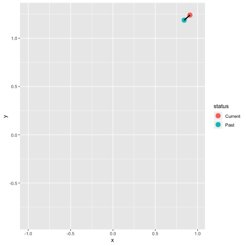

### Simple predictive regressions

In this section, we will consider a linear model:
$$f_t\left(x_{s,j}^{(1)}, \dots, x_{s,j}^{(K)}\right)=\alpha_t+\sum_{k=1}^K\beta_{t}^{(k)}x_{s,j}^{(k)},$$

where the parameters alpha and beta are estimated via simple **O**rdinary **L**east **S**quares. In the above expression, we do not refer to the error term, but do not forget that it exists!

First, we have a look on the full sample (using data_u).

```r
lm(F_Return ~ ., data = data_u) %>% summary() # Regression output
```

```
Call:
lm(formula = F_Return ~ ., data = data_u)

Residuals:
     Min       1Q   Median       3Q      Max
-0.68433 -0.03964  0.00147  0.04256  1.21885

Coefficients:
             Estimate Std. Error t value Pr(>|t|)
(Intercept)  0.021847   0.005142   4.249 2.18e-05 ***
Mkt_Cap     -0.020842   0.004146  -5.027 5.11e-07 ***
P2B         -0.006489   0.003706  -1.751   0.0800 .
Vol_1M       0.002892   0.003692   0.783   0.4335
RSI_1M      -0.006836   0.003622  -1.887   0.0592 .
D2E         -0.007617   0.003775  -2.018   0.0436 *
Prof_Marg    0.009145   0.004066   2.249   0.0245 *
---
Signif. codes:  0 ‘***’ 0.001 ‘**’ 0.01 ‘*’ 0.05 ‘.’ 0.1 ‘ ’ 1

Residual standard error: 0.08411 on 6593 degrees of freedom
Multiple R-squared:  0.005494,  Adjusted R-squared:  0.004589
F-statistic: 6.071 on 6 and 6593 DF,  p-value: 2.373e-06
```

As a confirmation of our previous exercise, **Mkt_Cap** stands out, meaning that the addition of other predictors does not alter its impact on future returns.

### Portfolio implications

```r
weights_multi <- function(past_data, curr_data, j){
    if(j == 1){ # j = 1 => regression-based
        fit <- lm(F_Return ~ ., data = past_data)   # Training on past data
        pred <- predict(fit, curr_data)             # Prediction
        w <- pred > mean(pred)                      # Investment decision: TRUE  = 1
        return(w / sum(w))
    }
    if(j == 2){ # j = 2 => EW
        N <- nrow(curr_data)
        return(rep(1/N,N))
    }
}
```

We then **initiate** the backtesting variables.

```r
t_all <- unique(data$Date)              # Set of dates
sep_date <- as.Date("2010-01-01")       # This date separates in-sample vs out-of-sample
t_oos <- t_all[t_all > sep_date]        # Out-of-sample dates (i.e., testing set)
nb_port <- 2                                                    # Nb of portfolios
Tt <- length(t_oos)                                             # Nb dates
portf_weights <- array(0, dim = c(Tt, nb_port, length(tick)))   # Store weights
portf_returns <- matrix(0, nrow = Tt, ncol = nb_port)           # Store returns
```

Finally, we are ready for the **backtesting** loop.

```r
data_u <- data.frame(data_u, Date = data$Date)              # We recover the dates from original file
for(t in 1:length(t_oos)){
    past_data <- data_u %>%                                 # The source is data_u!
        filter(Date < t_oos[t]) %>%                         # Past dates: expanding window!
        select(-Date)                                       # Take out dates
    curr_data <- data_u %>%                                 # The source is data_u!
        filter(Date == t_oos[t]) %>%                        # Current date
        select(-Date)                                       # Take out dates
    for(j in 1:nb_port){                                    # The loop on the strategies
        portf_weights[t,j,] <- weights_multi(past_data,     # Portfolio weights...
                                             curr_data,
                                             j)             # The weights' function is indexed by j
        realised_returns <- data_u %>%                      # Realised returns: take data_u
            filter(Date ==  t_oos[t]) %>%                   # Filter the right date
            select(F_Return)                                # Take the returns only
        portf_returns[t,j] <- sum(portf_weights[t,j,] * realised_returns) # Porfolio returns
    }
}
portf_returns %>% apply(2, mean) # Average return
```

```
[1] 0.010764065 0.009353351
```

```r
portf_returns %>% apply(2, sd)   # Volatility
```

```
[1] 0.04124354 0.03815350
```

The regression-based allocation is slightly more profitable, but also more volatile: in the end, both Sharpe ratios are close. In order to statistically assess whether a strategy is significantly preferable, it is possible to perform a **t-test** on the difference of returns.

```r
t_test <- t.test(portf_returns[,1]-portf_returns[,2])
t_test
```

```
    One Sample t-test

data:  portf_returns[, 1] - portf_returns[, 2]
t = 1.3987, df = 98, p-value = 0.1651
alternative hypothesis: true mean is not equal to 0
95 percent confidence interval:
 -0.0005908533  0.0034122803
sample estimates:
  mean of x
0.001410714
```

The difference is not sufficiently pronounced. A **t-stat** of 1.399 is not negligible, but not impressive either.

## One last thing…

### Consistency in persistence!

Inputs in financial backtesting can all be considered as time-series. There are many ways these tools can be characterised, but we underline one important property: **persistence**. One simply way to assess persistence is to compute **auto-correlations**.

```r
acf_2 <- function(v){    # We build a function that keeps the first order correlation
    return(acf(v, lag.max = 1, plot = FALSE)$acf[2])
}
data %>% group_by(Tick) %>% summarise_if(is.numeric, acf_2) # We apply this function to features
```

| Tick | Close | Mkt_Cap | P2B | Vol_1M | RSI_1M | D2E | Prof_Marg | F_Return |
| --- | --- | --- | --- | --- | --- | --- | --- | --- |
| AAPL | 0.9803201 | 0.9834064 | 0.9484243 | 0.6698586 | 0.5776433 | 0.9759562 | 0.9525285 | -0.0014295365 |
| BA | 0.9481282 | 0.9500100 | 0.8603447 | 0.7302098 | 0.5429457 | 0.8576750 | 0.7093260 | 0.0476573819 |
| BAC | 0.9846770 | 0.9507363 | 0.9380001 | 0.8971120 | 0.4558791 | 0.9433130 | 0.8039210 | 0.0078201606 |
| C | 0.9908679 | 0.9733400 | 0.9814688 | 0.8943614 | 0.4337429 | 0.9866070 | 0.7512128 | -0.0661636880 |
| CSCO | 0.9438543 | 0.9475038 | 0.9280454 | 0.8141988 | 0.4466708 | 0.9674010 | 0.7160633 | -0.1009231890 |
| CVS | 0.9906329 | 0.9896525 | 0.9607326 | 0.7106706 | 0.4963822 | 0.9444241 | 0.7363221 | -0.0037466519 |
| CVX | 0.9793159 | 0.9759749 | 0.9574208 | 0.7695632 | 0.4065765 | 0.9753169 | 0.8511649 | -0.1522092072 |
| D | 0.9813749 | 0.9773258 | 0.9643057 | 0.7198634 | 0.3078136 | 0.9486959 | 0.6550204 | -0.0999889370 |
| DIS | 0.9864783 | 0.9859750 | 0.9743406 | 0.7776783 | 0.5013863 | 0.9546287 | 0.8797781 | 0.0575725356 |
| F | 0.9186111 | 0.9679474 | 0.7903902 | 0.7670274 | 0.4723937 | 0.7779844 | 0.7699914 | 0.0782006665 |

[output cut: 20 more lines]

Almost all attributes are highly **autocorrelated** at the monthly frequency. This is obviously true for **Mkt_Cap** and **Vol_1M** which are indeed expected to show some memory over time.

The **main issue** is that the last column, which is the predicted variable, is not persistent at all! Hence, this is a major problem because it is unlikely that any good is going to come out of a model - even a very sophisticated one. If the returns are oscillating very quickly while the predictors have very smooth trajectories, then there is a **framing issue**. What will probably happen is that the model/algorithm will find spurious relationships/arbitrages between variables that will fail out-of-sample.

### Dealing with persistence

Two solutions (at least) exist:

1. either get rid of the persistence of the predictors (and keep the original dependent variable). One way to achieve this is to compute **variations** (relative $\Delta X_t=X_t/X_{t-1}-1$ or absolute $\Delta X_t=X_t-X_{t-1}$). In this case, it is the change in feature value that is expected to explain the change in prices.
2. or change the computation of the dependent variable to make it more persistent. This is easily done by **augmenting the horizon of the returns**.

Below, we provide examples of implementation for each alternative. We start with the second one.

```r
data_1 <- data  %>%
    group_by(Tick) %>%                                   # Grouping
    mutate(F_Return = lead(Close) / Close - 1,           # Adding 1M future returns
           FL_Return = lead(Close, 12) / Close - 1) %>%  # Adding 12M (Long-term) future returns
    na.omit() %>%                                        # Take out missing data
    ungroup()                                            # Ungrouping
data_1 %>% group_by(Tick) %>% summarise(autocor = acf_2(FL_Return)) # Showing the results
```

| Tick | autocor |
| --- | --- |
| AAPL | 0.9269673 |
| BA | 0.9075572 |
| BAC | 0.8119933 |
| C | 0.8364290 |
| CSCO | 0.8958665 |
| CVS | 0.9031453 |
| CVX | 0.8750229 |
| D | 0.8398985 |
| DIS | 0.9044822 |
| F | 0.9103024 |

[output cut: 20 more lines]

By looking 12 months ahead, we are smoothing the dependent variable, but we are also losing some data points. The result (in terms of autocorrelation patterns) is nonetheless satisfactory.

Finally, we turn to feature differences, which is the first option.

```r
data_2 <- data %>%
    group_by(Tick) %>%                                          # Group by stock
    mutate(D_Mkt_Cap = Mkt_Cap / lag(Mkt_Cap) - 1,              # Relative variation: scale issue
                          D_P2B = P2B - lag(P2B),               # Absolute variation for the rest
                          D_Vol_1M = Vol_1M - lag(Vol_1M),
                          D_RSI_1M = RSI_1M - lag(RSI_1M),
                          D_D2E = D2E - lag(D2E),
                          D_Prof_Marg = Prof_Marg - lag(Prof_Marg)) %>%
    na.omit() %>%                                               # Take out missing data
    ungroup()                                                   # Ungroup!
data_2 %>% group_by(Tick) %>% summarise_if(is.numeric, acf_2)   # Show the results
```

| Tick | Close | Mkt_Cap | P2B | Vol_1M | RSI_1M | D2E | Prof_Marg | F_Return | D_Mkt_Cap | D_P2B | D_Vol_1M | D_RSI_1M | D_D2E | D_Prof_Marg |
| --- | --- | --- | --- | --- | --- | --- | --- | --- | --- | --- | --- | --- | --- | --- |
| AAPL | 0.9802486 | 0.9833360 | 0.9482002 | 0.6652709 | 0.5806102 | 0.9759626 | 0.9524068 | 0.010125439 | 0.007224369 | -0.034332742 | -0.14261620 | -0.2188575 | -3.106868e-02 | -6.268995e-04 |
| BA | 0.9482622 | 0.9502779 | 0.8603082 | 0.7287749 | 0.5436504 | 0.8575990 | 0.7093235 | 0.056742352 | 0.086422667 | 0.036842121 | -0.13116073 | -0.2707026 | -3.583229e-04 | -1.992725e-04 |
| BAC | 0.9846904 | 0.9505482 | 0.9377493 | 0.8966449 | 0.4565175 | 0.9431998 | 0.8036995 | 0.007867134 | 0.047651557 | -0.005934759 | -0.06043435 | -0.2977948 | -1.093056e-03 | -3.340596e-05 |
| C | 0.9902767 | 0.9732132 | 0.9788590 | 0.8944704 | 0.4338916 | 0.9866064 | 0.7511876 | -0.063784144 | 0.038360146 | -0.048663653 | 0.02495425 | -0.2468956 | -1.072065e-03 | -9.393996e-04 |
| CSCO | 0.9357666 | 0.9392161 | 0.9259493 | 0.8145322 | 0.4420505 | 0.9672279 | 0.7167895 | -0.105416807 | -0.100254406 | -0.058440122 | -0.34005353 | -0.3128951 | -1.651589e-02 | -1.973901e-03 |
| CVS | 0.9903720 | 0.9894121 | 0.9629593 | 0.7044963 | 0.4957403 | 0.9443755 | 0.7361649 | -0.007438126 | -0.006759498 | 0.110350159 | -0.14745493 | -0.3009456 | -1.285070e-03 | -5.384622e-04 |
| CVX | 0.9791160 | 0.9755837 | 0.9568352 | 0.7692681 | 0.4028381 | 0.9747391 | 0.8511270 | -0.153689499 | -0.161926068 | -0.232937319 | 0.06178657 | -0.3082303 | -2.279833e-03 | -1.361173e-06 |
| D | 0.9817827 | 0.9773834 | 0.9652531 | 0.7206510 | 0.3081330 | 0.9486279 | 0.6547315 | -0.085164460 | -0.058264654 | -0.109263286 | -0.17192020 | -0.3113401 | -3.556097e-04 | -2.914437e-04 |
| DIS | 0.9870076 | 0.9866201 | 0.9735349 | 0.7754751 | 0.4989410 | 0.9544972 | 0.8792003 | 0.066906477 | 0.044609999 | -0.037344630 | -0.18415699 | -0.2584587 | -4.173038e-05 | -1.942916e-03 |
| F | 0.9166788 | 0.9687503 | 0.7903314 | 0.7681857 | 0.4729760 | 0.7777035 | 0.7698466 | 0.076217874 | 0.116822860 | 0.068482342 | -0.28691708 | -0.2524778 | -1.958138e-07 | -2.525793e-06 |

[output cut: 20 more lines]

**Finally**, do not hesitate to work with relative performance with respect to a benchmark. For instance, removing the cross-sectional average return at each point in time will single out the stocks with above-average performance. Moreover, the cross-sectional average of this indicator is not time-varying and subject to macro-economics fluctuations.

## Exercises

### Labelling

Feature engineering is not all: labelling is also very important. Recycle the code above to change the dependent variable (future returns) into:

1. a binary variable equal to zero when the future return is negative and to one when it is positive.
2. a binary variable equal to zero when the future return is below the cross-sectional average and to one when it is above.
3. a ternary variable equal to zero when the return is between [-r,r], to one if it is above r and to -1 if it is below -r, where r is a user-specified threshold.
4. a variable that assess the probability (frequency) of positive return over the next year.
5. a variable that assess the probability (frequency) of outpeforming the market (CS average) over the next year.

### Strategies with categorical data

Create a weighting scheme (function) that is based on categorical output (-1,0,1). The weights are initialised uniformly, then * if the output is 1, then the prior weight is one  
* if the output is -1, then the prior weight is zero  
* if the output is 0, then the prior weight is the sign of the previous weight  
* finally, normalise the prior weights so that they sum to one.

### Cross-sectional persistence

Verify if the persistence of attributes such as market capitalisation or volatility remains **after** the rescaling of features.